# Методы кодирования и модуляция сигналов

Лабораторная работа №1

Абдуллахи Шугофа

Российский университет дружбы народов, Москва, Россия

9 сентября 2025

# Цели и задачи работы

## Цель

Освоить методы кодирования и модуляции сигналов в Octave, изучить спектральные характеристики и проверить механизмы самосинхронизации.

## Задачи

- Построить и проанализировать составные синусоиды.
- Исследовать приближение меандра рядом Фурье.
- Рассчитать спектры гармонических сигналов и их суммы.
- Продемонстрировать амплитудную модуляцию (АМ) и её спектр.
- Сравнить схемы линейного кодирования и их самосинхронизацию.

# Визуализация функций в Octave

## Постановка

Построить графики функций *y*<sub>1</sub> и *y*<sub>2</sub> на
$$[−10;10]$$
:
$$y_1=\sin x+\tfrac13\sin 3x+\tfrac15\sin 5x,\;
y_2=\cos x+\tfrac13\cos 3x+\tfrac15\cos 5x$$

## Результаты

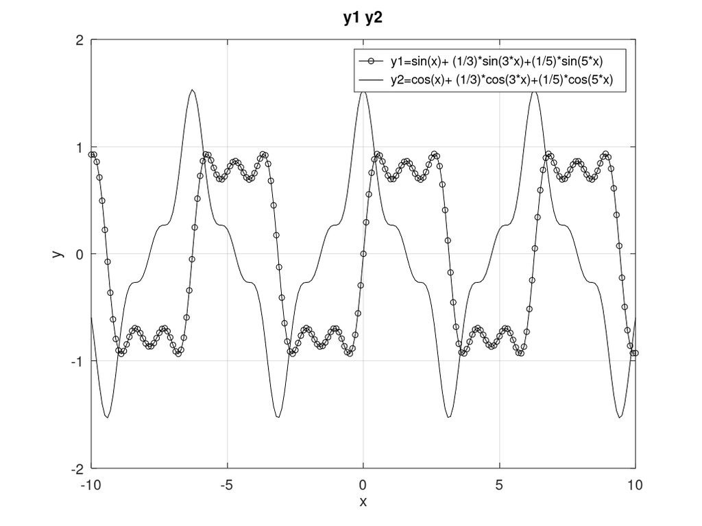

Графики функций y1 и y2

# Приближение меандра рядом Фурье

## Подход

- Нечётные гармоники до 8-й; амплитуда ∝ 1/*n*.
- Сравнение cos- и sin-разложений.

## Наблюдения

- При малом числе гармоник сигнал близок к синусу.
- С ростом гармоник фронты круче; проявляется эффект Гиббса.
- Оба разложения дают сопоставимое приближение.

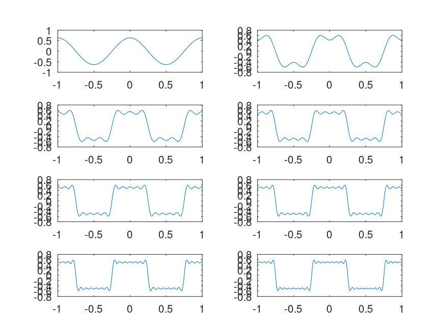

Меандр через cos-ряд

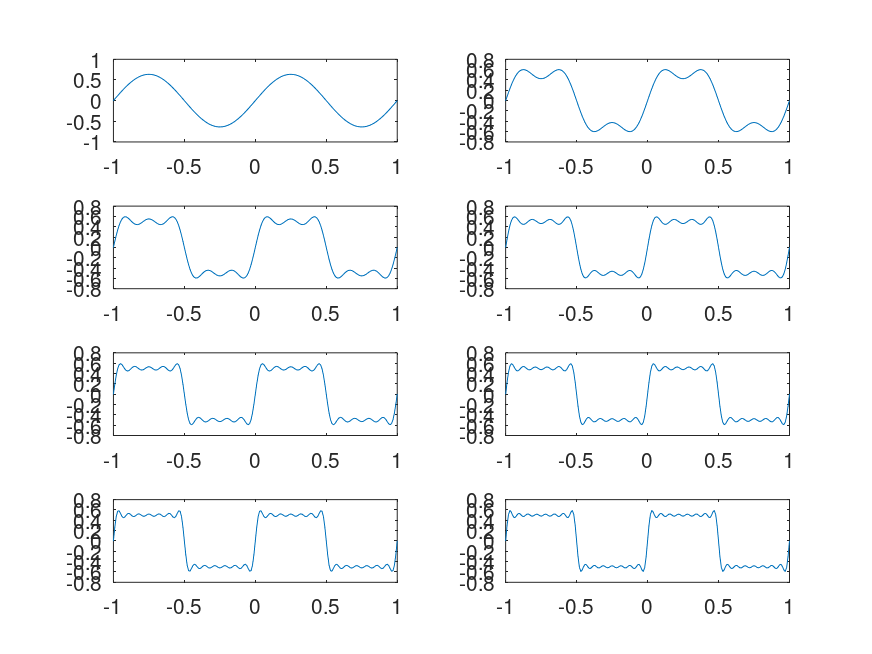

Меандр через sin-ряд

# Спектры и параметры сигналов

## Эксперимент

- *f*<sub>*s*</sub> = 512 Гц, *T* = 0.5 c.
- *s*<sub>1</sub>(*t*) = sin (2*π*⋅10*t*), *s*<sub>2</sub>(*t*) = 0.7sin (2*π*⋅40*t*).
- Спектры отдельных сигналов и их суммы.

## Выводы

- Пики спектра соответствуют 10 и 40 Гц.
- Суммарный спектр ≈ суперпозиция отдельных.
- При *f*<sub>*s*</sub> < 80 Гц возникает алиасинг (нарушение Найквиста).

## Выводы

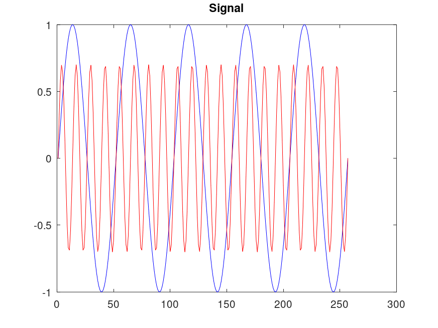

Два синусоидальных сигнала

## Выводы

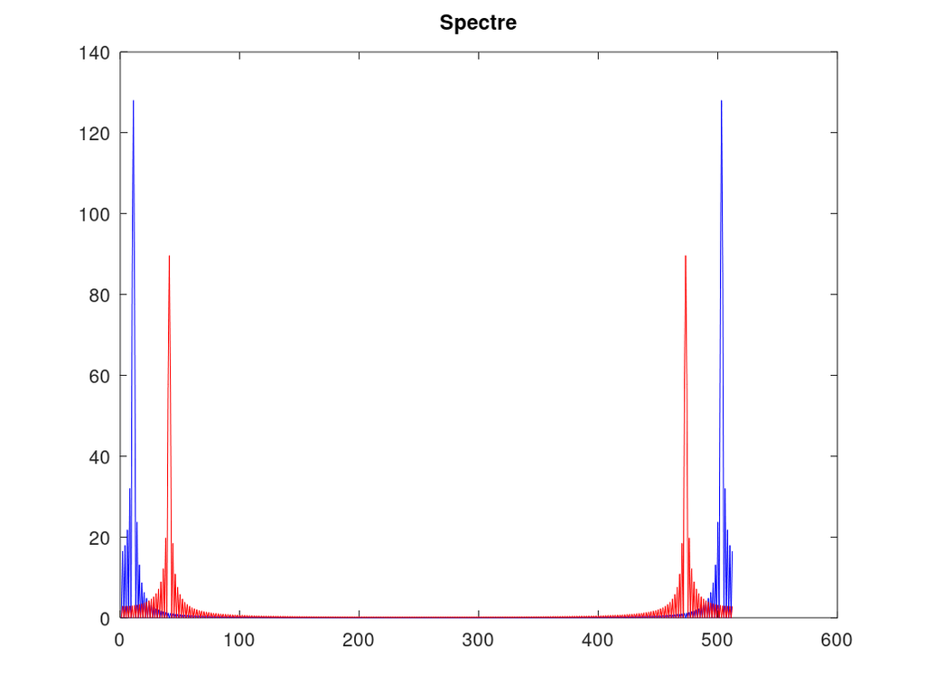

Спектры сигналов

## Выводы

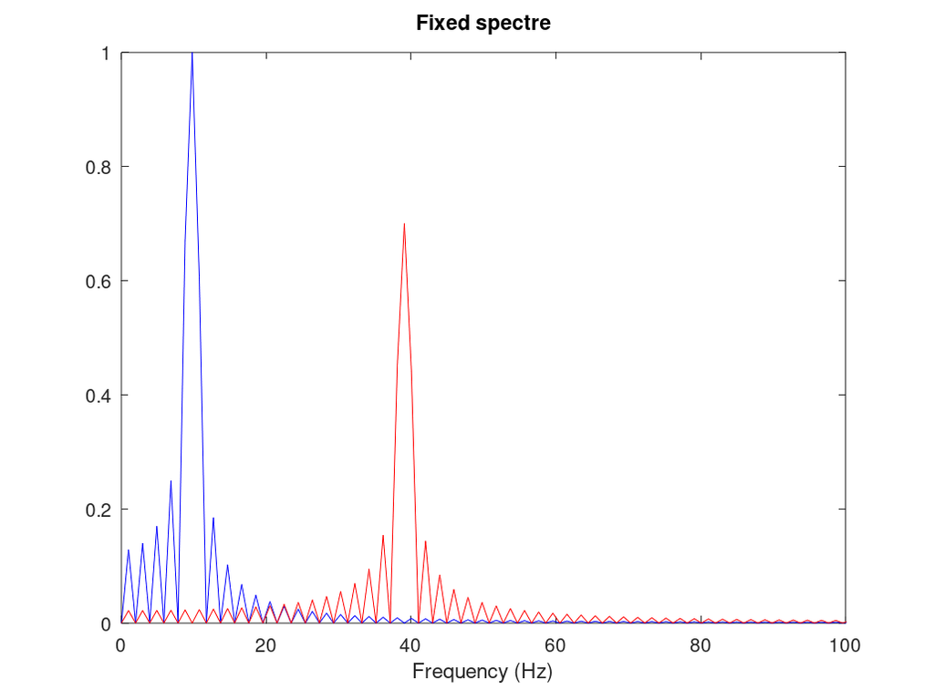

Исправленный спектр

## Выводы

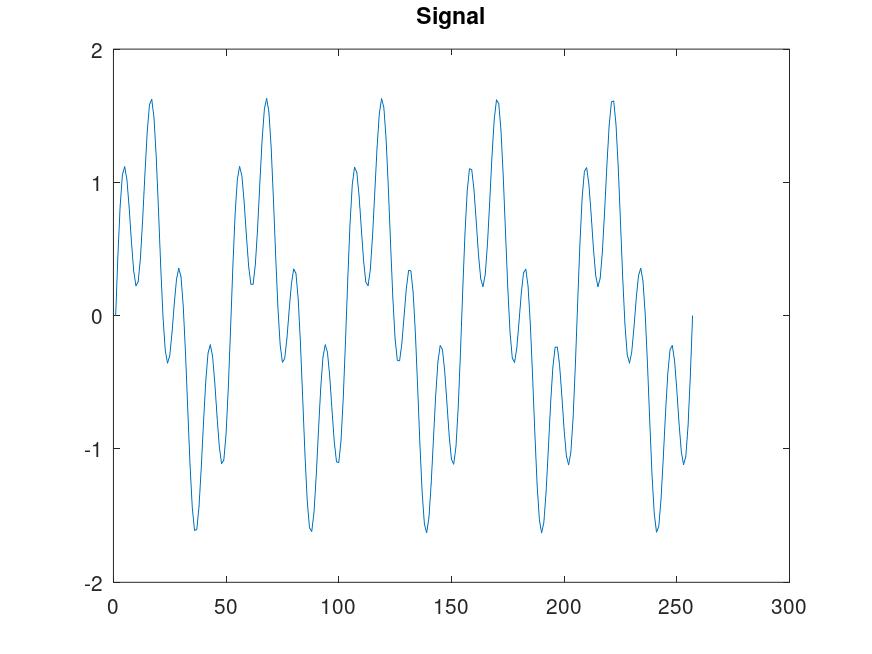

Суммарный сигнал

## Выводы

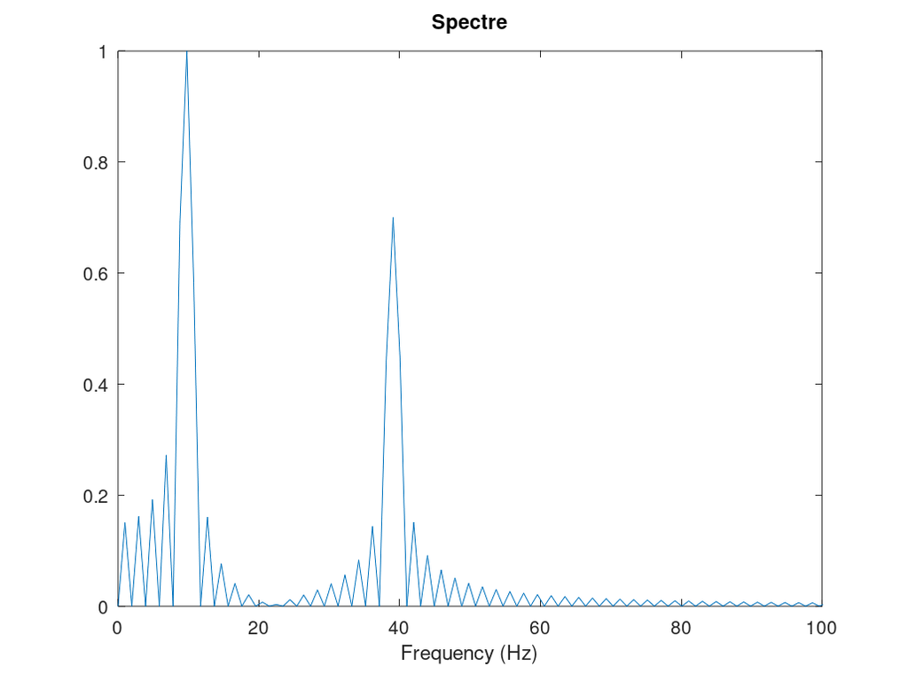

Спектр суммы

# Демонстрация амплитудной модуляции

## Постановка

- *f*<sub>*s*</sub> = 512 Гц, *T* = 0.5 c.
- Модулирующий: 5 Гц; несущая: 50 Гц.
- *s*(*t*) = *s*<sub>1</sub>(*t*) ⋅ *s*<sub>2</sub>(*t*). Построить огибающую и спектр.

## Итоги

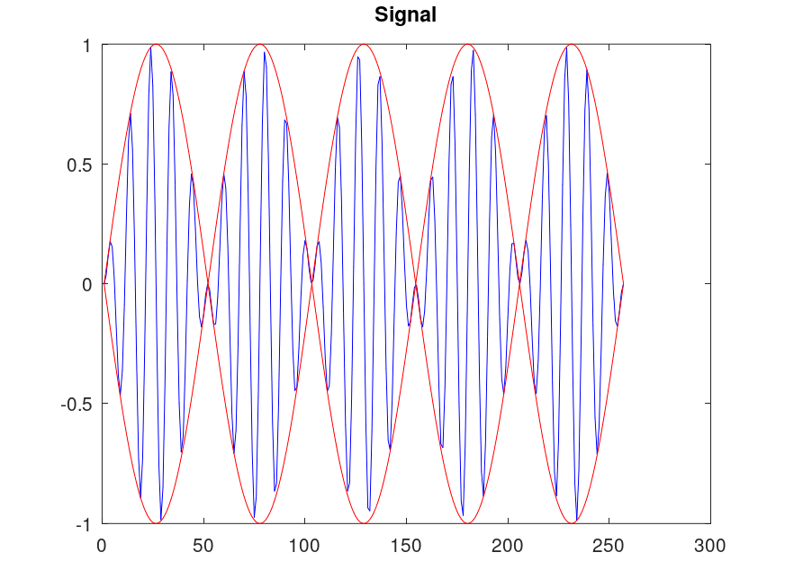

АМ-сигнал и огибающая

## Итоги

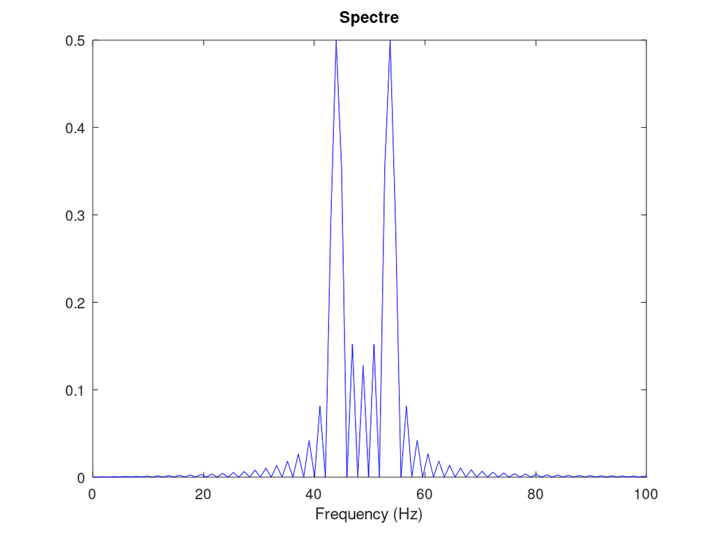

Спектр АМ-сигнала

# Линейное кодирование и самосинхронизация

## Схемы

Unipolar, AMI, Bipolar NRZ, Bipolar RZ, Manchester, Differential Manchester.

## Ключевые свойства

- **Unipolar**: DC-составляющая; проблемы с сериями нулей.
- **AMI**: чередование полярности единиц устраняет DC; нули — уязвимость.
- **Bipolar NRZ**: слабая самосинхронизация при длинных сериях.
- **Bipolar RZ**: возврат к нулю — лучше синхронизация, шире спектр.
- **Manchester**: переход в середине такта — надёжная синхронизация.
- **Diff. Manchester**: устойчив к инверсии полярности канала.

# Заключение